# Proyecto Fundamentos de Python: Análisis de Datos de FoodHub

**Puntos: 60**

### Contexto

El número de restaurantes en Nueva York aumenta día a día. Muchos estudiantes y profesionales ocupados confían en esos restaurantes debido a su estilo de vida agitado. El servicio de entrega de alimentos en línea es una gran opción para ellos. Les proporciona buena comida de sus restaurantes favoritos. Una empresa de agregación de alimentos, FoodHub, ofrece acceso a múltiples restaurantes a través de una sola aplicación para teléfonos inteligentes.

La aplicación permite a los restaurantes recibir un pedido directo en línea de un cliente. La aplicación asigna un repartidor de la empresa para que recoja el pedido después de que el restaurante lo confirme. El repartidor luego usa el mapa para llegar al restaurante y espera el paquete de comida. Una vez entregado el paquete de comida al repartidor, éste confirma la recolección en la app y se desplaza hasta el domicilio del cliente para entregar la comida. El repartidor confirma la entrega en la aplicación, después de entregar el paquete de comida al cliente. El cliente puede calificar el pedido en la aplicación. El agregador de alimentos gana dinero cobrando un margen fijo de la orden de entrega de los restaurantes.

### Objetivo

La empresa agregadora de alimentos ha almacenado los datos de los diferentes pedidos realizados por los clientes registrados en su portal online. Quieren analizar los datos para tener una idea clara de la demanda de los diferentes restaurantes, que les ayudará a mejorar la experiencia de sus clientes. Suponga que lo contratan como científico de datos en esta empresa y el equipo de ciencia de datos ha compartido algunas de las preguntas clave que deben responderse. Realice el análisis de datos para encontrar respuestas a estas preguntas que ayudarán a la empresa a mejorar el negocio.

### Descripción de los datos

Los datos contienen información relacionada con el pedido de comida. El diccionario de datos detallado se proporciona a continuación.

### Diccionario de datos

- order_id: ID único del pedido
- customer_id: ID del cliente que ordenó la comida
- restaurant_name: Nombre del restaurante
- cuisine_type: Tipo de cocina ordenada por el cliente
- cost: Coste del pedido
- day_of_the_week: Indica si el pedido se realiza en dia de semana o fin de semana (El dia de semana es de lunes a viernes y el fin de semana es sabado y domingo)
- rating: Calificación otorgada por el cliente sobre 5
- food_preparation_time: Tiempo (en minutos) que tarda el restaurante en preparar la comida. Esto se calcula tomando la diferencia entre las marcas de tiempo de la confirmación del pedido del restaurante y la confirmación de recolección del repartidor.
- delivery_time: Tiempo (en minutos) que tarda el repartidor en entregar el paquete de comida. Esto se calcula tomando la diferencia entre las marcas de tiempo de la confirmación de recolección del repartidor y la información de entrega.

### Comencemos importando las librerías requeridas

```python
# import libraries for data manipulation
import numpy as np
import pandas as pd

# import libraries for data visualization
import matplotlib.pyplot as plt
import seaborn as sns
```

```python
pd.set_option('display.float_format', lambda x: '%.3f' % x)
```

### Entender la estructura de los datos

```python
# uncomment and run the following lines for Google Colab
# from google.colab import drive
# drive.mount('/content/drive')
```

```python
# read the data
df = pd.read_csv('foodhub_order.csv')
# returns the first 5 rows
df.head()
```

|  | order_id | customer_id | restaurant_name | cuisine_type | cost_of_the_order | day_of_the_week | rating | food_preparation_time | delivery_time |
| --- | --- | --- | --- | --- | --- | --- | --- | --- | --- |
| 0 | 1477147 | 337525 | Hangawi | Korean | 30.750 | Weekend | Not given | 25 | 20 |
| 1 | 1477685 | 358141 | Blue Ribbon Sushi Izakaya | Japanese | 12.080 | Weekend | Not given | 25 | 23 |
| 2 | 1477070 | 66393 | Cafe Habana | Mexican | 12.230 | Weekday | 5 | 23 | 28 |
| 3 | 1477334 | 106968 | Blue Ribbon Fried Chicken | American | 29.200 | Weekend | 3 | 25 | 15 |
| 4 | 1478249 | 76942 | Dirty Bird to Go | American | 11.590 | Weekday | 4 | 25 | 24 |

#### Observaciones:

El DataFrame tiene 9 columnas como se menciona en el Diccionario de datos. Los datos de cada fila corresponden a un pedido realizado por un cliente.

### **Pregunta 1:** ¿Cuántas filas y columnas hay en los datos? [0.5 puntos]

```python
# Write your code here
print("There are", df.shape[0], 'rows and', df.shape[1], "columns.")
```

```
There are 1898 rows and 9 columns.
```

#### Observaciones:

Con este codigo podemos visualizar la estructura de nuestro dataframe, el cual contiene 1898 filas y 9 columnas

### **Pregunta 2:** ¿Cuáles son los tipos de datos de las diferentes columnas en el conjunto de datos? (Se puede usar la función info()) [0.5 puntos]

```python
# Use info() to print a concise summary of the DataFrame
df.info()
```

```
<class 'pandas.core.frame.DataFrame'>
RangeIndex: 1898 entries, 0 to 1897
Data columns (total 9 columns):
 #   Column                 Non-Null Count  Dtype
---  ------                 --------------  -----
 0   order_id               1898 non-null   int64
 1   customer_id            1898 non-null   int64
 2   restaurant_name        1898 non-null   object
 3   cuisine_type           1898 non-null   object
 4   cost_of_the_order      1898 non-null   float64
 5   day_of_the_week        1898 non-null   object
 6   rating                 1898 non-null   object
 7   food_preparation_time  1898 non-null   int64
 8   delivery_time          1898 non-null   int64
dtypes: float64(1), int64(4), object(4)
memory usage: 133.6+ KB
```

#### Observaciones:

Aqui podemos ver un resumen del dataframe más a detalle.

### **Pregunta 3:** ¿Falta algún valor en los datos? Si es así, trátelos usando un método apropiado. [1 punto]

```python
# Write your code here
data_new['rating'].unique()
```

```
array([nan,  5.,  3.,  4.])
```

```python
data_new['rating'].apply(type).value_counts()
```

```
rating
<class 'float'>    1898
Name: count, dtype: int64
```

```python
data_new.isnull().sum()
```

```
order_id                   0
customer_id                0
restaurant_name            0
cuisine_type               0
cost_of_the_order          0
day_of_the_week            0
rating                   736
food_preparation_time      0
delivery_time              0
dtype: int64
```

```python
data_new.duplicated().sum()
```

```
0
```

```python
data_new['rating'].dtype
```

```
dtype('float64')
```

#### Observaciones:

Para esta pregunta primero se crea un nuevo dataframe (el codigo se encuentra más abajo en la seccion de analisis bivariado) el cual es llamado, data_new. en este nuevo dataframe los valores "not given" de la variable "rating" son asignados como valores NaN, los cuales los podemos contar con la funcion isnull().sum().

### **Pregunta 4:** Verifique el resumen estadístico de los datos. ¿Cuál es el tiempo mínimo, promedio y máximo que se tarda en preparar la comida una vez que se hace el pedido? [2 puntos]

```python
# Write your code here
df.describe().T
```

|  | count | mean | std | min | 25% | 50% | 75% | max |
| --- | --- | --- | --- | --- | --- | --- | --- | --- |
| order_id | 1898.000 | 1477495.500 | 548.050 | 1476547.000 | 1477021.250 | 1477495.500 | 1477969.750 | 1478444.000 |
| customer_id | 1898.000 | 171168.478 | 113698.140 | 1311.000 | 77787.750 | 128600.000 | 270525.000 | 405334.000 |
| cost_of_the_order | 1898.000 | 16.499 | 7.484 | 4.470 | 12.080 | 14.140 | 22.297 | 35.410 |
| food_preparation_time | 1898.000 | 27.372 | 4.632 | 20.000 | 23.000 | 27.000 | 31.000 | 35.000 |
| delivery_time | 1898.000 | 24.162 | 4.973 | 15.000 | 20.000 | 25.000 | 28.000 | 33.000 |

#### Observaciones:

Con esta funcion podemos verificar el resumen estaditico de los datos, asi podemos darnos cuenta que el tiempo mínimo, promedio y máximo para preparar la comida una vez que se hace el pedido es de: 20, 27.37 y 35 min respectivamente.

### **Pregunta 5:** ¿Cuántos pedidos no tienen rating (valoración)? [1 punto]

```python
pd.DataFrame({'Count':data_new.isnull().sum()[data_new.isnull().sum()>0]})
```

|  | Count |
| --- | --- |
| rating | 736 |

#### Observaciones:

Con este codigo se genera un nuevo dataframe que se utiliza solo para mostrar la cantidad de valores nulos en cada columna del dataframe. en este caso la unica columna que no tiene valores asignados es la columna de "rating", siendo 736 ordenes sin calificacion.

### Análisis exploratorio de datos (EDA)

### **Pregunta 6:** Explore todas las variables y proporcione observaciones sobre sus distribuciones. (Por lo general, se utilizan histogramas, diagramas de caja, countplots, etc. para la exploración univariada.) [9 puntos]

```python
# Write the code here
print(df.columns)
```

```
Index(['order_id', 'customer_id', 'restaurant_name', 'cuisine_type',
       'cost_of_the_order', 'day_of_the_week', 'rating',
       'food_preparation_time', 'delivery_time'],
      dtype='object')
```

Cost of the order

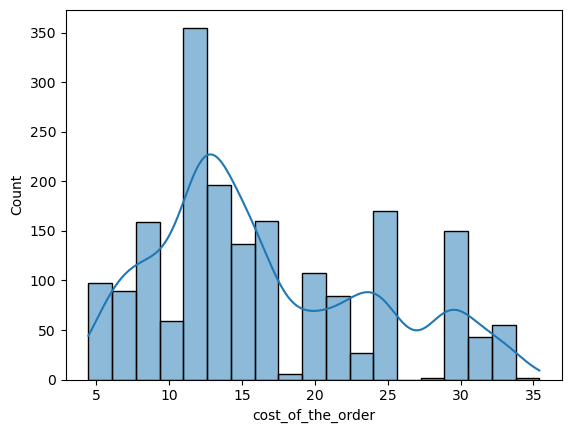

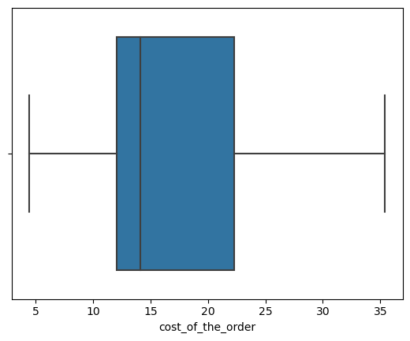

```python
sns.histplot(data=df,x='cost_of_the_order', kde = True)
plt.show()
sns.boxplot(data=df,x='cost_of_the_order')
plt.show()
```

Rating

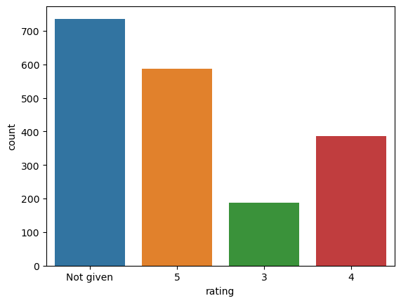

```python
sns.countplot(data = df, x = 'rating')
```

Observaciones: en esta countplot a mi opinion me parecio prudente utilizar el df que no tenia los valores "NaN" para poder tener visualizar cuantas ordenes no tienen una calificacion asignada, quiza esto se deba que los usuarios no tengan el interes de calificar las ordenes, sin tener que relacionar alguna otra variable con esto.

T. de preparacion de alimentos

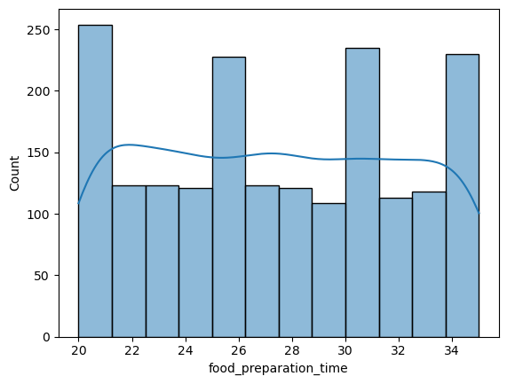

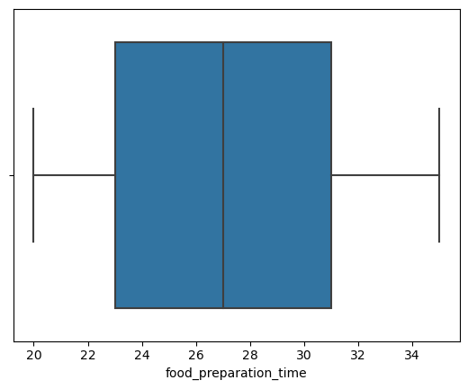

```python
sns.histplot(data=df,x='food_preparation_time', kde = True)
plt.show()
sns.boxplot(data=df,x='food_preparation_time')
plt.show()
```

Observaciones: podemos ver los datos no cuentan con una distribucion normal, y que la mitad de los datos se encuentra ente los 27 minutos de preparacion. sin presentar valores atipicos.

T. de entrega

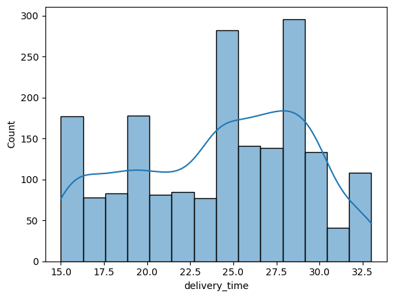

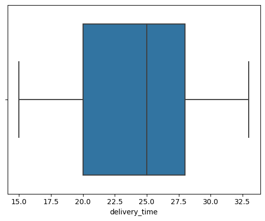

```python
sns.histplot(data=df,x='delivery_time' , kde = True)
plt.show()
sns.boxplot(data=df,x='delivery_time')
plt.show()
```

```python
D. de la semana
```

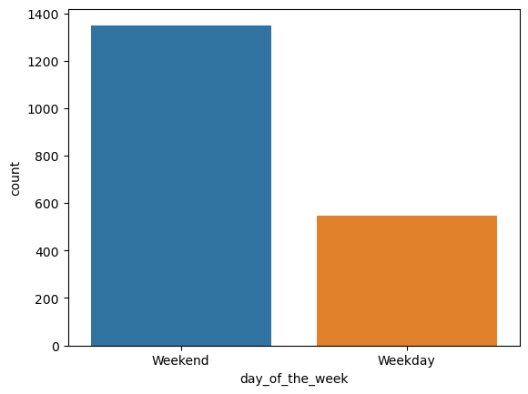

```python
sns.countplot(data = df, x = 'day_of_the_week')
```

Observaciones: aqui se hace un conteo el cual nos muestra que durante los fines de semana se generan más pedidos que entre semana. denotando una correlacion positiva.

```python
Tipo de cocina
```

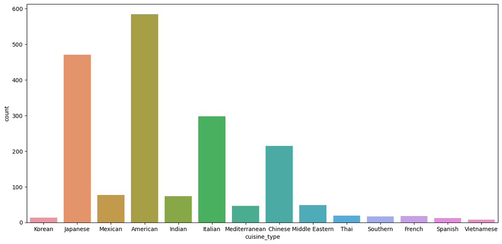

```python
plt.figure(figsize = (15,7))
sns.countplot(data = df, x = 'cuisine_type')
```

Observaciones: lo que podemos ver en esta grafica son los tipo de cocina mas consumidos en la aplicacion, siendo el top 3 de cocinas: americana, japonesa e italiana.

### **Pregunta 7**: ¿Cuáles son los 5 mejores restaurantes en cuanto al número de pedidos recibidos? [1 punto]

```python
# Write the code here
df['restaurant_name'].value_counts().head(5)
```

```
restaurant_name
Shake Shack                  219
The Meatball Shop            132
Blue Ribbon Sushi            119
Blue Ribbon Fried Chicken     96
Parm                          68
Name: count, dtype: int64
```

#### Observaciones:

En esta pregunta se realiza un value_counts() de los nombres de los restaurantes a los cuales se les hacen más pedidos, y se muestran los 5 primeros.

siendo 1.- shake shack 2.- the meatball shop 3.- blue ribbon sushi 4.- blue ribbon fried chicken 5.- parm.

teniendo una relacion con lo que hemos visto previamente en la countplot. mostrando restaurantes de comida americana, japones e italiana en los primeros 5 lugares con más ordenes.

### **Pregunta 8**: ¿Cuál es la cocina más popular los fines de semana? [1 punto]

```python
# Write the code here
df[df['day_of_the_week'] == 'Weekend']['cuisine_type'].value_counts()
```

```
cuisine_type
American          415
Japanese          335
Italian           207
Chinese           163
Mexican            53
Indian             49
Mediterranean      32
Middle Eastern     32
Thai               15
French             13
Korean             11
Southern           11
Spanish            11
Vietnamese          4
Name: count, dtype: int64
```

#### Observaciones:

En esta pregunta se realizan un conteo filtrado en el dataframe, en la columna "day_of_the_week" la cual nos indica si un pedido fue realizado entre semana o el fin de semana. de esta manera podemos ver que las cocinas mas populares los fines de semana sin las mismas que antes se mencionaron. Americana, japonesa e italiana.

### **Pregunta 9**: ¿Qué porcentaje de los pedidos cuesta más de 20 dólares? [2 puntos]

```python
# Write the code here
total_pedidos = df.shape[0]
pedidos_mas_20 = df[df['cost_of_the_order'] > 20].shape[0]
porcentaje = (pedidos_mas_20 / total_pedidos) * 100
print(f'El porcentaje de pedidos que cuestan más de 20 dólares es: {porcentaje:.2f}%')
```

```
El porcentaje de pedidos que cuestan más de 20 dólares es: 29.24%
```

#### Observaciones:

En esta pregunta se obtiene el numero total de pedidos usando el .shape(0), esto devuelve el numero de filas, despues se filtran los pedidos con un costo mayor a 20 dolares usando una condicion y se obtiene el numero de filas resultantes, en la tecera linea se calcula el porcentaje dividiendo el numero de pedidos que cuestan más de 20 dolares entre el total de pedidos y multiplicandolo por 100, al final se imprime la respuesta la cual nos da que el 29.24% de los pedidos cuesta mas de 20 dolares.

### **Pregunta 10**: ¿Cuál es el tiempo medio de entrega del pedido? [1 punto]

```python
# Write the code here
tiempo_medio_entrega = df['delivery_time'].mean()

print(f'El tiempo medio de entrega del pedido es: {tiempo_medio_entrega:.2f} minutos')
```

```
El tiempo medio de entrega del pedido es: 24.16 minutos
```

#### Observaciones:

Para esta pregunta primero se utiliza la funcion .mean() para calcular el promedio del tiempo de entrega de la columna "delivery_time" del df, despues se imprime un mensaje con formato el cual nos muestra el tiempo medio de entrega de los pedidos. El cual es de: 24.16 minutos.

### **Pregunta 11:** La empresa ha decidido dar cupones de descuento del 20% a los 3 clientes más frecuentes. Encuentre las identificaciones de estos clientes y la cantidad de pedidos que realizaron. [1 punto]

```python
# Write the code here
df['customer_id'].value_counts().head(3)
```

```
customer_id
52832    13
47440    10
83287     9
Name: count, dtype: int64
```

#### Observaciones:

En esta pregunta se realiza un .value_counts() especificando que nos muestre las 3 primeras posiciones con mas pedidos con la funcion .head(3) de esta manera podemos ver cuales son los clientes más frecuentes y así ofrecerles su descuento.

# Analisis multivariable

### **Pregunta 12**: Realice un análisis multivariado para explorar las relaciones entre las variables importantes en el conjunto de datos. (Es una buena idea explorar las relaciones entre variables numéricas, así como las relaciones entre variables numéricas y categóricas) [10 puntos]

```python
# Write the code here
print(df.columns)
```

```
Index(['order_id', 'customer_id', 'restaurant_name', 'cuisine_type',
       'cost_of_the_order', 'day_of_the_week', 'rating',
       'food_preparation_time', 'delivery_time'],
      dtype='object')
```

```python
data_new=pd.read_csv('foodhub_order.csv',na_values=['Not given'])
```

```python
data_new.describe().T
```

|  | count | mean | std | min | 25% | 50% | 75% | max |
| --- | --- | --- | --- | --- | --- | --- | --- | --- |
| order_id | 1898.000 | 1477495.500 | 548.050 | 1476547.000 | 1477021.250 | 1477495.500 | 1477969.750 | 1478444.000 |
| customer_id | 1898.000 | 171168.478 | 113698.140 | 1311.000 | 77787.750 | 128600.000 | 270525.000 | 405334.000 |
| cost_of_the_order | 1898.000 | 16.499 | 7.484 | 4.470 | 12.080 | 14.140 | 22.297 | 35.410 |
| rating | 1162.000 | 4.344 | 0.741 | 3.000 | 4.000 | 5.000 | 5.000 | 5.000 |
| food_preparation_time | 1898.000 | 27.372 | 4.632 | 20.000 | 23.000 | 27.000 | 31.000 | 35.000 |
| delivery_time | 1898.000 | 24.162 | 4.973 | 15.000 | 20.000 | 25.000 | 28.000 | 33.000 |

```python
cat_cols =  ['rating']
for column in cat_cols:
    print(data_new[column].value_counts())
    print("-" * 50)
```

```
rating
5.000    588
4.000    386
3.000    188
Name: count, dtype: int64
--------------------------------------------------
```

Comparación de variables

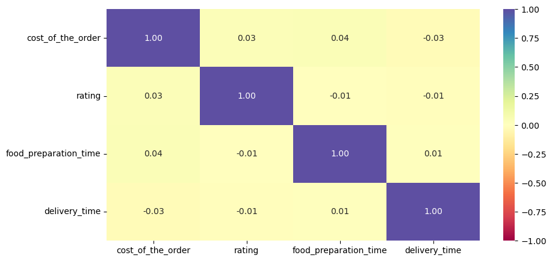

```python
data_numeric = data_new.drop(['restaurant_name', 'order_id', 'customer_id', 'cuisine_type', 'day_of_the_week'], axis=1)

# Calcular la matriz de correlación
correlation_matrix = data_numeric.corr()

# Generar el heatmap de correlación
plt.figure(figsize=(10, 5))
sns.heatmap(correlation_matrix, annot=True, cmap='Spectral',fmt=".2f", vmin=-1, vmax=1)
plt.show()
```

Observaciones: aqui podemos ver que las variables no tienen una correlacion lineal tan signficativa entre si y por lo tanto no deberian de tener un efecto tan notable entre ellas.

tiempo de entrega y calif

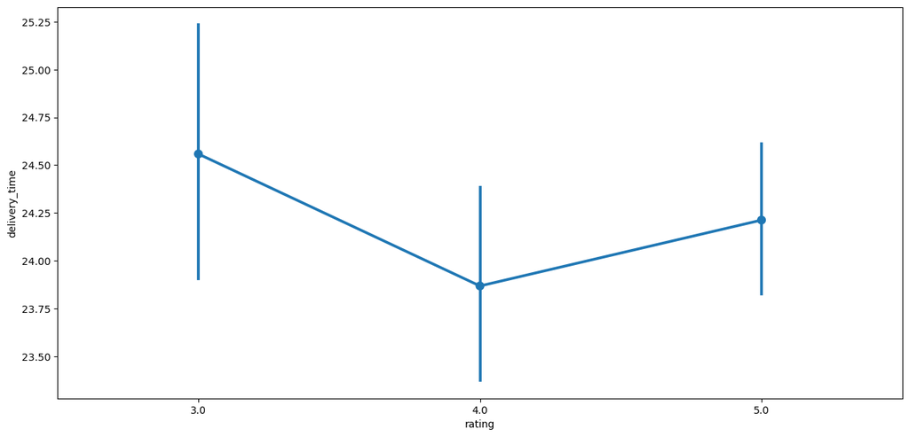

```python
plt.figure(figsize=(15, 7))
sns.pointplot(x = 'rating', y = 'delivery_time', data = data_new)
plt.show()
```

Observaciones: podemos ver que que a medida que hay un mejor rating, los tiempos de entrega bajan, pero hay algo interesante que se debe de comentar y es que los pedidos con 5 de calificacion, que se considera una calificacion más alta, son mas tardardados que los pedidos con calificacion 4, esto se podria deber a que factores adicionales, como una preparacion más meticulosa o una mejor atencion a los detalles de los platillos.

tipo de cocina y costo del pedido

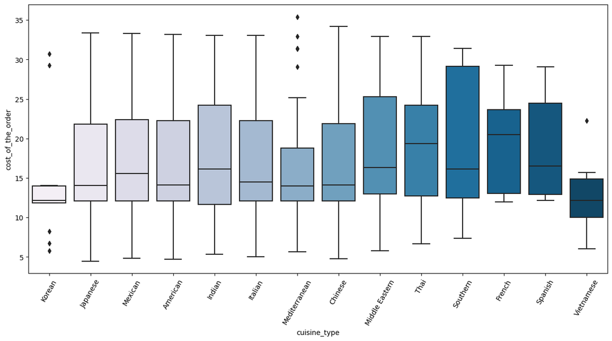

```python
plt.figure(figsize=(15,7))
sns.boxplot(x = "cuisine_type", y = "cost_of_the_order", data = df, palette = 'PuBu')
plt.xticks(rotation = 60)
plt.show()
```

Observaciones: podemos observar que en la cocina coreana se encuentran valores atipicos tanto a la izquierda como a la derecha de los bigotes, lo que nos indica que existen pedidos con costos mas bajos de lo normal como pedidos con costos mas altos de lo normal en comparacion con las demas cocinas.

tambien podemos decir que en la cocina mediterranea y la cocina vietnamita hay veces que existen pedido mas caros que los que comunmente se hacen.

esto nos puede indicar que quiza en la comida coreana exista una mayor variabilidad y por lo tanto exista una mayor diversidad de precios en sus menus, mientras que en las otras 2 cocinas tienden a tener articulos mas caros en general, pero sin tanta variabilidad en los precios mas bajos.

tipo de cocina y tiempo de preparacion

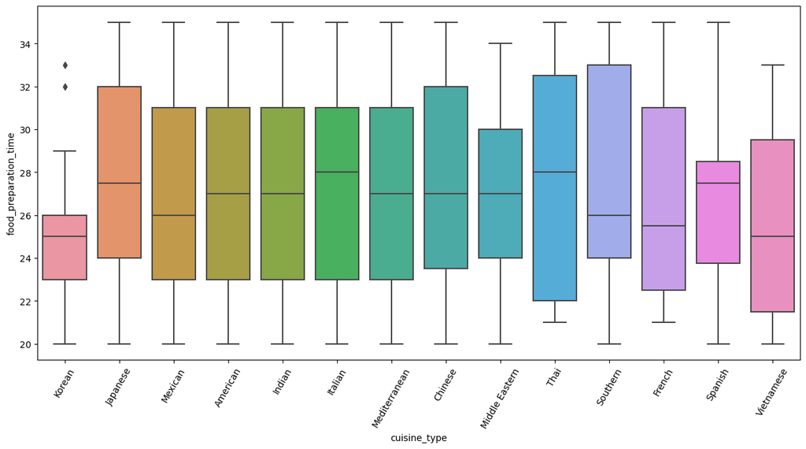

```python
plt.figure(figsize=(15,7))
sns.boxplot(x='cuisine_type', y='food_preparation_time', data=df)
plt.xticks(rotation=60)
plt.show()
```

Observaciones: en esta boxplot podemos ver que los unicos valores atipicos que encontramos estan en la cocina coreana, lo cual podria deberse a que en su menu, se encuentren articulos los cuales tengan un proceso mas complejo de elaboracion pero que no se piden muy a menudo.

calificacion vs tiempo de preparacion

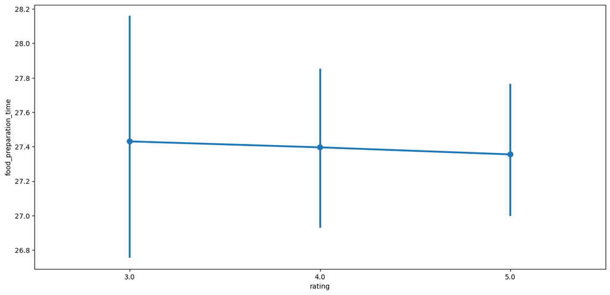

```python
plt.figure(figsize=(15, 7))
sns.pointplot(x='rating', y='food_preparation_time', data=data_new)
plt.show()
```

Observaciones: podemos ver que a medida que la calificación otorgada por los clientes aumenta, se observa una tendencia hacia tiempos de preparación un poco más cortos, se podria decir que los restaurantes con mejores calificaciones tienen a ser mas eficientes a la hora de preparar sus pedidos. Aunque tambien podemos ver que existe una mayor variabilidad en las ordenes con calificacion de 3 ya que algunos pedidos pueden tener un tiempo corto o en otros casos un tiempo de preparacion mas largo.

Calif y costo del pedido

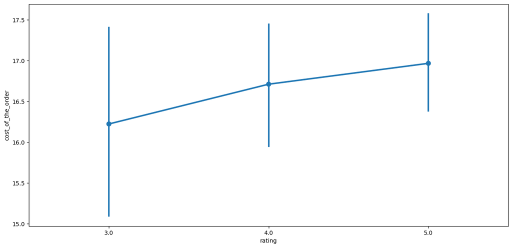

```python
plt.figure(figsize=(15, 7))
sns.pointplot(x='rating', y='cost_of_the_order', data=data_new)
plt.show()
```

Observaciones: podemos observar que a medida que el rating aumenta, ligeramente el costo igual aumenta, es interesante ver que los restaurantes mejor calificados tambien ofrezcan platos mas costosos. lo que nos puede indicar que tienen una mejor calidad o experiencia culinaria, por otro lado podemos ver que los que tienen calificacion de 3 nuevamente tienen una gran variabilidad, demostrando que incluso dentro de una misma calificacion, el costo puede variar significativamente.

```python
dia de la semana y tiempo de entrega
```

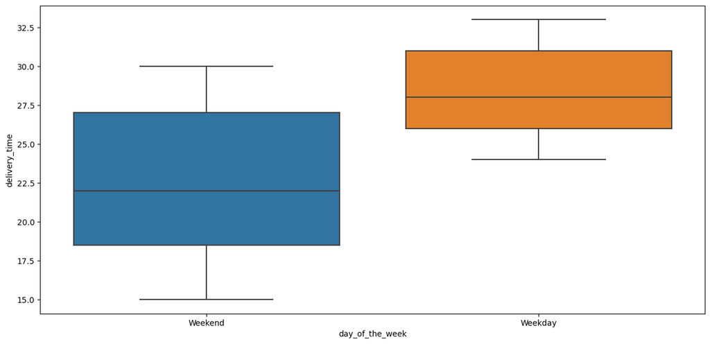

```python
plt.figure(figsize=(15,7))
sns.boxplot(x='day_of_the_week', y='delivery_time', data=data_new)
plt.show()
```

Observaciones: en este grafico podemos observar que la caja de weekend tiene una mayor variabilidad en los tiempos de entrega durante esos dias, ademas de sus datos abarcan un rango mas amplio, desde el timepo minimo hasta alrededor de los 30 minutos.

la caja de weekday es mas estrecha, por lo que sugiere que durante los dias laborales, el tiempo de entrga tiende a ser mas consistente y mantiene un rango mas estrecho.

esto nos puede indicar que aunque en los dias laborales, puedes llegar a esperar un poco mas de tiempo a que te entregen tu comida, los tiempos de entrega seran mas constantes a comparacion del fin de semana, esto puede deberse a factores como la demanda del cliento o las operaciones que se realicen en los restaurantes los diferentes dias de la semana.

### **Pregunta 13:** La empresa quiere ofrecer una oferta promocional en la publicidad de los restaurantes. La condición para obtener la oferta es que los restaurantes deben tener una calificación de más de 50 y la calificación promedio debe ser superior a 4. Encuentre los restaurantes que cumplen con los criterios para obtener la oferta promocional. [3 puntos]

```python
# Filter the rated restaurants
df_rated = df[df['rating'] != 'Not given'].copy()
df_rated['rating'] = df_rated['rating'].astype('float')
df_rating_count = df_rated.groupby(['restaurant_name'])['rating'].count().sort_values(ascending=False).reset_index()
rest_names = df_rating_count[df_rating_count['rating'] > 50]['restaurant_name']
df_mean_4 = df_rated[df_rated['restaurant_name'].isin(rest_names)].copy()
mean_ratings = df_mean_4.groupby(['restaurant_name'])['rating'].mean().sort_values(ascending=False).reset_index()
selected_restaurants = mean_ratings[mean_ratings['rating'] > 4]
selected_restaurants.head(3)
```

|  | restaurant_name | rating |
| --- | --- | --- |
| 0 | The Meatball Shop | 4.512 |
| 1 | Blue Ribbon Fried Chicken | 4.328 |
| 2 | Shake Shack | 4.278 |

#### Observaciones:

En esta pregunta explicare por linea lo que se realizo para encontrar la respuesta.

pirmera linea: se crea un nuevo df el cual contiene unicmanete las filas donde la columna rating no tiene el valor "not given", se utiliza .copy() para tener una copia independiente del df.

segunda linea: se convierte el tipo de datos de rating a float

tercera linea: se utiliza la funcion groupby.() para agrupar el df por el nombre del restaurante. se cuenta el numero de calificaciones que tiene para cada restaurante y se ordenan de manera descendente.

cuarta linea: se filtran los datos que tienen mas de 50 calificaciones. se selecciona el nombre del restaurante correspondiente y se almacena en la variable rest_names.

quinta linea: se filtran las filas que pertenecen a los restaurantes seleccionados en rest_names. se crea una copia independiente del df resultante y se almancena en df_mean_4.

sexta linea: se agrupa df_mean_4 por el nombre del restaurante y se calcula la calificacion promedio para cada restaurante. estos resultados se alamcenan en orden descendente. al final el resultado se almacena en mean_ratings.

septima linea: se filtran los restaurantes en mean ratings, que tienen una calificacion promedio superior a 4 y se muestran los 3 primeros.

aqui podemos ver de nuevo lo que hemos platicado en las preguntas anteriores. siendo los 3 restaurantes con mejores calificaciones, restaurantes con los tipos de cocina más consumidos. en este caso siendo la Americana y la Italiana.

### **Pregunta 14:** La empresa cobra al restaurante el 25% de las órdenes que tienen un costo mayor a 20 dólares y el 15% de las órdenes que tienen un costo mayor a 5 dólares. Encuentre los ingresos netos generados por la empresa en todos los pedidos. [3 puntos]

```python
# Write the code here
# Filtramos los pedidos que cuestan más de 20 dólares
pedidos_20 = df[df['cost_of_the_order'] > 20]
pedidos_5_20 = df[(df['cost_of_the_order'] > 5) & (df['cost_of_the_order'] <= 20)]
ingresos_20 = pedidos_20['cost_of_the_order'].sum() * 0.25
ingresos_5_20 = pedidos_5_20['cost_of_the_order'].sum() * 0.15
ingresos_totales = ingresos_20 + ingresos_5_20

print(ingresos_totales)
```

```
6166.303
```

#### Observaciones:

En esta pregunta primero se filtraron los pedidos que cuestan más de 20 dolares, despues se filtraron los pedidos que cuestan entre 5 y 20 dolares, se calcularon los ingresos para cada grupo de pedidos (25% y 15%) y despues se sumaron los ingresos para obtener los ingresos totales, los cuales son: 6166.303 dolares.

### **Pregunta 15:** La empresa quiere analizar el tiempo total requerido para entregar la comida. ¿Qué porcentaje de pedidos tardan más de 60 minutos en entregarse desde el momento en que se realiza el pedido? (La comida tiene que ser preparada y luego entregada.) [2 puntos]

```python
# Write the code here
df['total_time'] = df['food_preparation_time'] + df['delivery_time']
pedidos_largos = df[df['total_time'] > 60]
porcentaje = (len(pedidos_largos) / len(df)) * 100

print("El porcentaje de pedidos que tardan más de 60 minutos es: ", porcentaje, "%")
```

```
El porcentaje de pedidos que tardan más de 60 minutos es:  10.537407797681771 %
```

#### Observaciones:

Para esta pregunta primero, creamos una nueva columna para el tiempo total, despues encontramos cuantos pedidos tardan más de 60 minutos y al final se calcula el porcentaje. El cual nos indica que el % de pedidos que se tardan más de 60 minutos es de: 10.5374%

### **Pregunta 16:** La empresa quiere analizar el tiempo de entrega de los pedidos entre semana y fines de semana. ¿Cómo varía el tiempo medio de entrega entre semana y fines de semana? [2 puntos]

```python
# Write the code here
mean_delivery_time = df.groupby('day_of_the_week')['delivery_time'].mean()
print(mean_delivery_time)
diff = mean_delivery_time['Weekday'] - mean_delivery_time['Weekend']
print("La diferencia en el tiempo medio de entrega entre semana y fin de semana es ", diff, " minutos")
```

```
day_of_the_week
Weekday   28.340
Weekend   22.470
Name: delivery_time, dtype: float64
La diferencia en el tiempo medio de entrega entre semana y fin de semana es  5.870014357297798  minutos
```

#### Observaciones:

para esta pregunta, primero se calcula el mean_delivery_time, por medio de las funciones .groupby() y la funcion .mean(), despues de eso se calcula la diferencia de los tiempos medios de entrega entre semana y fin de semana. Podemos ver que la diferencia de entrega entre semana y fin de semana es de casi 6 minutos, siendo fin de semana la mas baja.

### Conclusión y Recomendaciones

### **Pregunta 17:** ¿Cuáles son sus conclusiones del análisis? ¿Qué recomendaciones le gustaría compartir para ayudar a mejorar el negocio? (Puede usar el tipo de cocina y el rating de los comentarios para impulsar sus recomendaciones de negocios). [6 puntos]

### Conclusiones:

despues de realizar el analisis de datos correspondiente, puedo llegar a la conclusion de que los mejores tipos de cocina que hay son:

Americana Italiana Japonesa

Por lo que se puede decir que existe una demanda significativa por parte de los clientes.

Aunque el restaurante con mejor calificacion sea italiano, las ventas de comida americana sobrepasan a las de comida italiana por el doble, siendo la causa quiza una preferencia de los clientes, ya que en cuanto a caracteristicas como tiempo de preparacion y costo son muy parecidas.

### Recomendaciones:

Como recomendacion, podria decir que el negocio se centre más en el top 5 de tipos de cocina con mejores calificaciones, proporcionandoles más herramientas como publicidad o promociones dentro de la aplicacion, para que asi las ventas crezcan más, de igual manera en este caso en especifico otra recomendacion seria que se buscara la manera de incentivar a los clientes a generar retroaliemntacion sobre los restaurantes, para tener una idea mas certera de sus gustos y poder ofrecerles el mejor de los servicios.